# Data Preprocessing

```python
import pandas as pd
```

```python
df = pd.read_csv('dataset.csv')
```

```python
df.head()
```

|  | age;"job";"marital";"education";"default";"housing";"loan";"contact";"month";"day_of_week";"duration";"campaign";"pdays";"previous";"poutcome";"emp.var.rate";"cons.price.idx";"cons.conf.idx";"euribor3… |
| --- | --- |
| 0 | 56;"housemaid";"married";"basic.4y";"no";"no";... |
| 1 | 57;"services";"married";"high.school";"unknown... |
| 2 | 37;"services";"married";"high.school";"no";"ye... |
| 3 | 40;"admin.";"married";"basic.6y";"no";"no";"no... |
| 4 | 56;"services";"married";"high.school";"no";"no... |

```python
df.info()
```

```
<class 'pandas.core.frame.DataFrame'>
RangeIndex: 41188 entries, 0 to 41187
Data columns (total 1 columns):
 #   Column                                                                                                                                                                                                                        Non-Null Count  Dtype
---  ------                                                                                                                                                                                                                        --------------  -----
 0   age;"job";"marital";"education";"default";"housing";"loan";"contact";"month";"day_of_week";"duration";"campaign";"pdays";"previous";"poutcome";"emp.var.rate";"cons.price.idx";"cons.conf.idx";"euribor3m";"nr.employed";"y"  41188 non-null  object
dtypes: object(1)
memory usage: 321.9+ KB
```

## Changing the delimiter -

```python
with open("dataset.csv", "r", encoding="utf-8") as f:
    lines = f.readlines()

data = [line.strip().replace('"', '').split(';') for line in lines]

df = pd.DataFrame(data[1:], columns=data[0])

df.to_csv("cleaned_dataset.csv", index=False)
```

```python
df = pd.read_csv('cleaned_dataset.csv')
```

```python
df.head()
```

|  | age | job | marital | education | default | housing | loan | contact | month | day_of_week | ... | campaign | pdays | previous | poutcome | emp.var.rate | cons.price.idx | cons.conf.idx | euribor3m | nr.employed | y |
| --- | --- | --- | --- | --- | --- | --- | --- | --- | --- | --- | --- | --- | --- | --- | --- | --- | --- | --- | --- | --- | --- |
| 0 | 56 | housemaid | married | basic.4y | no | no | no | telephone | may | mon | ... | 1 | 999 | 0 | nonexistent | 1.1 | 93.994 | -36.4 | 4.857 | 5191.0 | no |
| 1 | 57 | services | married | high.school | unknown | no | no | telephone | may | mon | ... | 1 | 999 | 0 | nonexistent | 1.1 | 93.994 | -36.4 | 4.857 | 5191.0 | no |
| 2 | 37 | services | married | high.school | no | yes | no | telephone | may | mon | ... | 1 | 999 | 0 | nonexistent | 1.1 | 93.994 | -36.4 | 4.857 | 5191.0 | no |
| 3 | 40 | admin. | married | basic.6y | no | no | no | telephone | may | mon | ... | 1 | 999 | 0 | nonexistent | 1.1 | 93.994 | -36.4 | 4.857 | 5191.0 | no |
| 4 | 56 | services | married | high.school | no | no | yes | telephone | may | mon | ... | 1 | 999 | 0 | nonexistent | 1.1 | 93.994 | -36.4 | 4.857 | 5191.0 | no |

5 rows × 21 columns

## Dataset Overview -

### Bank Client Data:

- age (numeric)
- job : type of job (categorical: "admin.","blue-collar","entrepreneur","housemaid","management","retired","self- employed","services","student","technician","unemployed","unknown")
- marital : marital status (categorical: "divorced","married","single","unknown"; note: "divorced" means divorced or widowed)
- education (categorical: "basic.4y","basic.6y","basic.9y","high.school","illiterate","professional.course","university.degree","unknown")
- default: has credit in default? (categorical: "no","yes","unknown")
- housing: has housing loan? (categorical: "no","yes","unknown")
- loan: has personal loan? (categorical: "no","yes","unknown")

### Related with the last contact of the current campaign:

- contact: contact communication type (categorical: "cellular","telephone")
- month: last contact month of year (categorical: "jan", "feb", "mar", ..., "nov", "dec")
- day_of_week: last contact day of the week (categorical: "mon","tue","wed","thu","fri")
- duration: last contact duration, in seconds (numeric). Important note: this attribute highly affects the output target (e.g., if duration=0 then y="no"). Yet, the duration is not known before a call is performed. Also, after the end of the call y is obviously known. Thus, this input should only be included for benchmark purposes and should be discarded if the intention is to have a realistic predictive model.

### Other attributes:

- campaign: number of contacts performed during this campaign and for this client (numeric, includes last contact)
- pdays: number of days that passed by after the client was last contacted from a previous campaign (numeric; 999 means client was not previously contacted)
- previous: number of contacts performed before this campaign and for this client (numeric)
- poutcome: outcome of the previous marketing campaign (categorical: "failure","nonexistent","success")

### Social and economic context attributes:

- emp.var.rate: employment variation rate - quarterly indicator (numeric)
- cons.price.idx: consumer price index - monthly indicator (numeric)
- cons.conf.idx: consumer confidence index - monthly indicator (numeric)
- euribor3m: euribor 3 month rate - daily indicator (numeric)
- nr.employed: number of employees - quarterly indicator (numeric)

### Output variable (desired target):

- y: has the client subscribed a term deposit? (binary: "yes","no")

## Datatype conversion to numeric -

```python
numeric_columns = ['age', 'campaign', 'pdays', 'previous', 'emp.var.rate', 'cons.price.idx', 'cons.conf.idx', 'euribor3m', 'nr.employed']

df[numeric_columns] = df[numeric_columns].apply(pd.to_numeric)
```

## Handling duplicates -

```python
duplicate = df[df.duplicated()]
duplicate
```

|  | age | job | marital | education | default | housing | loan | contact | month | day_of_week | ... | campaign | pdays | previous | poutcome | emp.var.rate | cons.price.idx | cons.conf.idx | euribor3m | nr.employed | y |
| --- | --- | --- | --- | --- | --- | --- | --- | --- | --- | --- | --- | --- | --- | --- | --- | --- | --- | --- | --- | --- | --- |
| 1266 | 39 | blue-collar | married | basic.6y | no | no | no | telephone | may | thu | ... | 1 | 999 | 0 | nonexistent | 1.1 | 93.994 | -36.4 | 4.855 | 5191.0 | no |
| 12261 | 36 | retired | married | unknown | no | no | no | telephone | jul | thu | ... | 1 | 999 | 0 | nonexistent | 1.4 | 93.918 | -42.7 | 4.966 | 5228.1 | no |
| 14234 | 27 | technician | single | professional.course | no | no | no | cellular | jul | mon | ... | 2 | 999 | 0 | nonexistent | 1.4 | 93.918 | -42.7 | 4.962 | 5228.1 | no |
| 16956 | 47 | technician | divorced | high.school | no | yes | no | cellular | jul | thu | ... | 3 | 999 | 0 | nonexistent | 1.4 | 93.918 | -42.7 | 4.962 | 5228.1 | no |
| 18465 | 32 | technician | single | professional.course | no | yes | no | cellular | jul | thu | ... | 1 | 999 | 0 | nonexistent | 1.4 | 93.918 | -42.7 | 4.968 | 5228.1 | no |
| 20216 | 55 | services | married | high.school | unknown | no | no | cellular | aug | mon | ... | 1 | 999 | 0 | nonexistent | 1.4 | 93.444 | -36.1 | 4.965 | 5228.1 | no |
| 20534 | 41 | technician | married | professional.course | no | yes | no | cellular | aug | tue | ... | 1 | 999 | 0 | nonexistent | 1.4 | 93.444 | -36.1 | 4.966 | 5228.1 | no |
| 25217 | 39 | admin. | married | university.degree | no | no | no | cellular | nov | tue | ... | 2 | 999 | 0 | nonexistent | -0.1 | 93.200 | -42.0 | 4.153 | 5195.8 | no |
| 28477 | 24 | services | single | high.school | no | yes | no | cellular | apr | tue | ... | 1 | 999 | 0 | nonexistent | -1.8 | 93.075 | -47.1 | 1.423 | 5099.1 | no |
| 32516 | 35 | admin. | married | university.degree | no | yes | no | cellular | may | fri | ... | 4 | 999 | 0 | nonexistent | -1.8 | 92.893 | -46.2 | 1.313 | 5099.1 | no |
| 36951 | 45 | admin. | married | university.degree | no | no | no | cellular | jul | thu | ... | 1 | 999 | 0 | nonexistent | -2.9 | 92.469 | -33.6 | 1.072 | 5076.2 | yes |
| 38281 | 71 | retired | single | university.degree | no | no | no | telephone | oct | tue | ... | 1 | 999 | 0 | nonexistent | -3.4 | 92.431 | -26.9 | 0.742 | 5017.5 | no |

12 rows × 21 columns

```python
df = df.drop_duplicates()
```

## Handling missing data values -

```python
missing_df = pd.DataFrame(df.isnull().sum())
missing_df
```

|  | 0 |
| --- | --- |
| age | 0 |
| job | 0 |
| marital | 0 |
| education | 0 |
| default | 0 |
| housing | 0 |
| loan | 0 |
| contact | 0 |
| month | 0 |
| day_of_week | 0 |
| duration | 0 |
| campaign | 0 |
| pdays | 0 |
| previous | 0 |
| poutcome | 0 |
| emp.var.rate | 0 |
| cons.price.idx | 0 |
| cons.conf.idx | 0 |
| euribor3m | 0 |
| nr.employed | 0 |
| y | 0 |

## Handling the 'unknown' data values -

```python
unknown_df = pd.DataFrame((df == 'unknown').sum() / len(df) * 100)
unknown_df
```

|  | 0 |
| --- | --- |
| age | 0.000000 |
| job | 0.801438 |
| marital | 0.194288 |
| education | 4.201477 |
| default | 20.876239 |
| housing | 2.404313 |
| loan | 2.404313 |
| contact | 0.000000 |
| month | 0.000000 |
| day_of_week | 0.000000 |
| duration | 0.000000 |
| campaign | 0.000000 |
| pdays | 0.000000 |
| previous | 0.000000 |
| poutcome | 0.000000 |
| emp.var.rate | 0.000000 |
| cons.price.idx | 0.000000 |
| cons.conf.idx | 0.000000 |
| euribor3m | 0.000000 |
| nr.employed | 0.000000 |
| y | 0.000000 |

```python
df = df[df['marital'] != 'unknown']
df = df[df['job'] != 'unknown']
```

## Dropping the 'duration' column -

```python
df = df.drop('duration', axis=1)
```

## Outlier detection using boxplots -

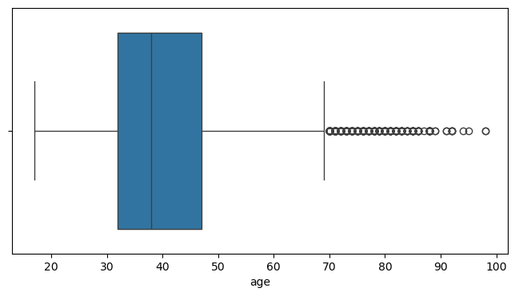

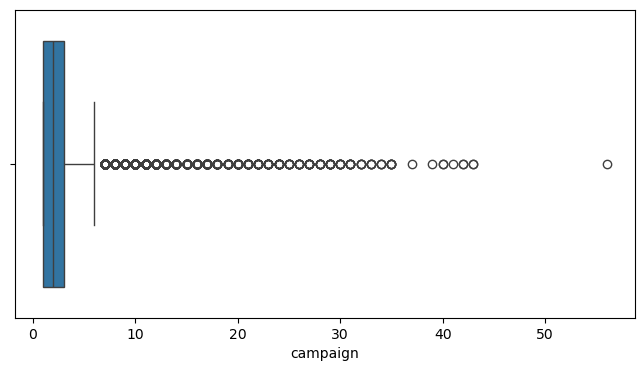

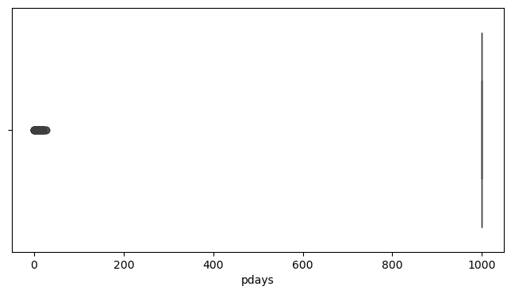

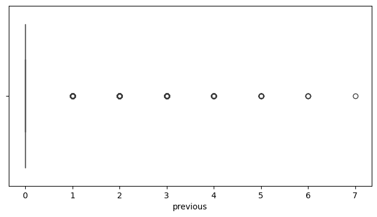

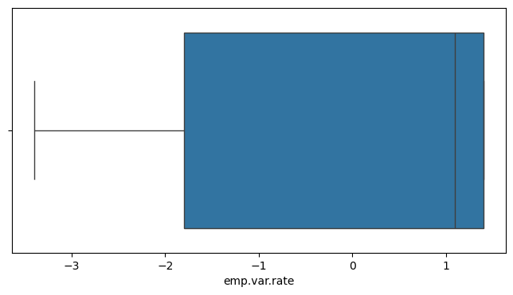

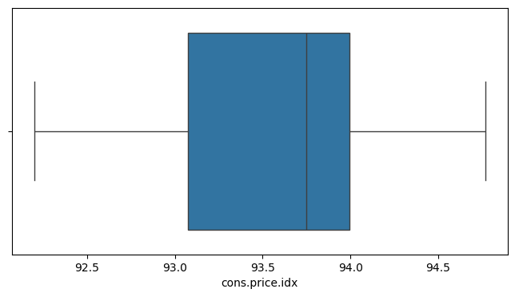

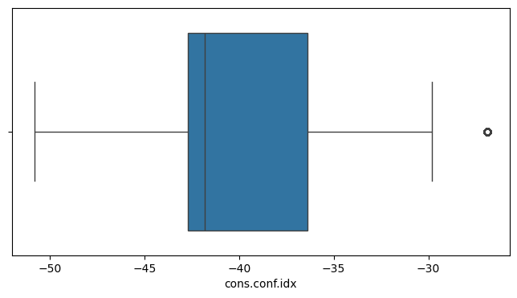

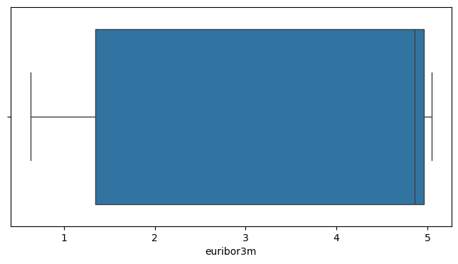

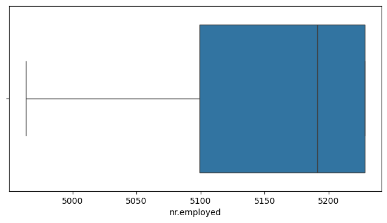

```python
import seaborn as sns
import matplotlib.pyplot as plt

plt.figure(figsize=(8, 4))
sns.boxplot(x=df['age'])
plt.show()

plt.figure(figsize=(8, 4))
sns.boxplot(x=df['campaign'])
plt.show()

plt.figure(figsize=(8, 4))
sns.boxplot(x=df['pdays'])
plt.show()

plt.figure(figsize=(8, 4))
sns.boxplot(x=df['previous'])
plt.show()

plt.figure(figsize=(8, 4))
sns.boxplot(x=df['emp.var.rate'])
plt.show()

plt.figure(figsize=(8, 4))
sns.boxplot(x=df['cons.price.idx'])
plt.show()

plt.figure(figsize=(8, 4))
sns.boxplot(x=df['cons.conf.idx'])
plt.show()

plt.figure(figsize=(8, 4))
sns.boxplot(x=df['euribor3m'])
plt.show()

plt.figure(figsize=(8, 4))
sns.boxplot(x=df['nr.employed'])
plt.show()
```

## Outlier detection using the IQR method -

```python
numeric_columns = ['age', 'campaign', 'pdays', 'previous', 'emp.var.rate', 'cons.price.idx', 'cons.conf.idx', 'euribor3m', 'nr.employed']

outlier_percentages = {}

for col in numeric_columns:
    Q1 = df[col].quantile(0.25)
    Q3 = df[col].quantile(0.75)
    IQR = Q3 - Q1
    lower_bound = Q1 - 1.5 * IQR
    upper_bound = Q3 + 1.5 * IQR

    outliers = df[(df[col] < lower_bound) | (df[col] > upper_bound)]
    percent_outliers = (len(outliers) / len(df)) * 100
    outlier_percentages[col] = round(percent_outliers, 2)

outlier_df = pd.DataFrame.from_dict(outlier_percentages, orient='index', columns=['Outlier %'])

outlier_df
```

|  | Outlier % |
| --- | --- |
| age | 1.13 |
| campaign | 5.82 |
| pdays | 3.65 |
| previous | 13.66 |
| emp.var.rate | 0.00 |
| cons.price.idx | 0.00 |
| cons.conf.idx | 1.07 |
| euribor3m | 0.00 |
| nr.employed | 0.00 |

## OHE of categorical features -

```python
ohe_cols = ['education', 'default', 'housing', 'loan', 'job', 'marital', 'contact', 'month', 'day_of_week', 'poutcome']

df = pd.get_dummies(df, columns=ohe_cols, drop_first=False)
```

## Performing label encoding and datatype conversion on the target 'y' -

```python
df['y'] = df['y'].map({'yes': 1, 'no': 0})

df['y'] = df.pop('y')

df['y'] = df['y'].astype(bool)
```

## Correlation analysis on numeric columns -

```python
df_numeric = df[numeric_columns]

corr = df_numeric.corr()
corr.style.background_gradient(cmap='coolwarm')
```

|  | age | campaign | pdays | previous | emp.var.rate | cons.price.idx | cons.conf.idx | euribor3m | nr.employed |
| --- | --- | --- | --- | --- | --- | --- | --- | --- | --- |
| age | 1.000000 | 0.003414 | -0.034230 | 0.024465 | -0.000586 | 0.000159 | 0.127881 | 0.010448 | -0.017610 |
| campaign | 0.003414 | 1.000000 | 0.052371 | -0.078932 | 0.150160 | 0.127052 | -0.013229 | 0.134621 | 0.143470 |
| pdays | -0.034230 | 0.052371 | 1.000000 | -0.586168 | 0.269956 | 0.078485 | -0.092240 | 0.295609 | 0.371244 |
| previous | 0.024465 | -0.078932 | -0.586168 | 1.000000 | -0.419486 | -0.202290 | -0.051704 | -0.453549 | -0.500352 |
| emp.var.rate | -0.000586 | 0.150160 | 0.269956 | -0.419486 | 1.000000 | 0.775292 | 0.198133 | 0.972231 | 0.906802 |
| cons.price.idx | 0.000159 | 0.127052 | 0.078485 | -0.202290 | 0.775292 | 1.000000 | 0.061180 | 0.687997 | 0.521496 |
| cons.conf.idx | 0.127881 | -0.013229 | -0.092240 | -0.051704 | 0.198133 | 0.061180 | 1.000000 | 0.279367 | 0.102142 |
| euribor3m | 0.010448 | 0.134621 | 0.295609 | -0.453549 | 0.972231 | 0.687997 | 0.279367 | 1.000000 | 0.945131 |
| nr.employed | -0.017610 | 0.143470 | 0.371244 | -0.500352 | 0.906802 | 0.521496 | 0.102142 | 0.945131 | 1.000000 |

## Using Variation Inflation Factor (VIF) to measure the amount of multicollinearity -

```python
from statsmodels.stats.outliers_influence import variance_inflation_factor
from statsmodels.tools.tools import add_constant

X = add_constant(df[numeric_columns])

vif = pd.DataFrame()
vif['feature'] = X.columns
vif['VIF'] = [variance_inflation_factor(X.values, i) for i in range(X.shape[1])]
print(vif)
```

```
          feature            VIF
0           const  529178.488786
1             age       1.018425
2        campaign       1.033281
3           pdays       1.608952
4        previous       1.791291
5    emp.var.rate      33.087332
6  cons.price.idx       6.342704
7   cons.conf.idx       2.645638
8       euribor3m      64.279331
9     nr.employed      31.649421
```

## Dropping highly correlated features -

```python
df.drop(['euribor3m', 'nr.employed'], axis=1, inplace=True)
```

## Recalculating VIF -

```python
numeric_columns = ['age', 'campaign', 'pdays', 'previous', 'emp.var.rate', 'cons.price.idx', 'cons.conf.idx']

X = add_constant(df[numeric_columns])

vif = pd.DataFrame()
vif['feature'] = X.columns
vif['VIF'] = [variance_inflation_factor(X.values, i) for i in range(X.shape[1])]
print(vif)
```

```
          feature           VIF
0           const  71863.225169
1             age      1.018222
2        campaign      1.025667
3           pdays      1.601893
4        previous      1.743881
5    emp.var.rate      3.356323
6  cons.price.idx      2.760853
7   cons.conf.idx      1.127746
```

# Predictive Analysis

```python
import numpy as np
import seaborn as sns
from sklearn import metrics
from sklearn.model_selection import train_test_split
from sklearn.metrics import classification_report, confusion_matrix, roc_auc_score, roc_curve, accuracy_score, precision_score, recall_score, f1_score
import matplotlib.pyplot as plt
```

## Splitting the dataset -

```python
X = df.drop('y', axis=1)
y = df['y']

X_train, X_test, y_train, y_test = train_test_split(X, y, test_size=0.3, random_state=25)
```

## Scalling the input data -

```python
from sklearn.preprocessing import StandardScaler

sc_X = StandardScaler()
X_train_scaled = sc_X.fit_transform(X_train)
X_test_scaled = sc_X.fit_transform(X_test)
```

## 1) Logistic Regression

```
Logistic Regression Report:
              precision    recall  f1-score   support

       False       0.91      0.98      0.94     10832
        True       0.65      0.24      0.35      1401

    accuracy                           0.90     12233
   macro avg       0.78      0.61      0.65     12233
weighted avg       0.88      0.90      0.88     12233
```

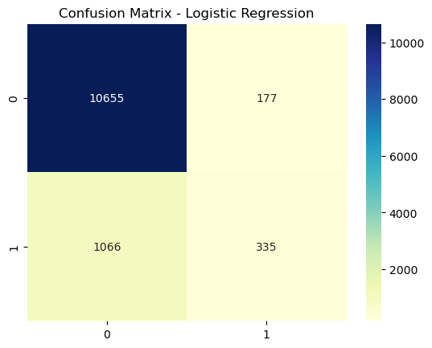

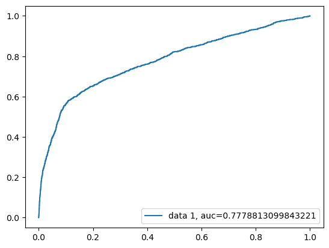

```python
from sklearn.linear_model import LogisticRegression

lr = LogisticRegression(max_iter=2000)
lr.fit(X_train_scaled, y_train)

y_pred = lr.predict(X_test_scaled)
y_prob = lr.predict_proba(X_test_scaled)[:,1]

print("Logistic Regression Report:")
print(classification_report(y_test, y_pred))

sns.heatmap(confusion_matrix(y_test, y_pred), annot=True, cmap="YlGnBu" ,fmt='g')
plt.title("Confusion Matrix - Logistic Regression")
plt.show()

y_pred_proba = lr.predict_proba(X_test_scaled)[::,1]
fpr, tpr, _ = metrics.roc_curve(y_test,  y_pred_proba)
auc = metrics.roc_auc_score(y_test, y_pred_proba)
plt.plot(fpr,tpr,label="data 1, auc="+str(auc))
plt.legend(loc=4)
plt.show()
```

## 2) KNN

```
K-Nearest Neighbors Report:
              precision    recall  f1-score   support

       False       0.91      0.97      0.94     10832
        True       0.52      0.24      0.33      1401

    accuracy                           0.89     12233
   macro avg       0.71      0.61      0.63     12233
weighted avg       0.86      0.89      0.87     12233
```

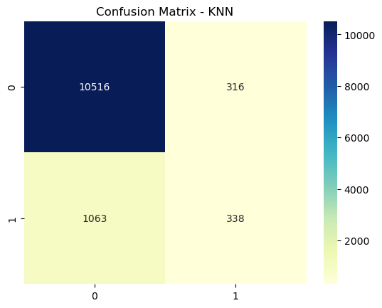

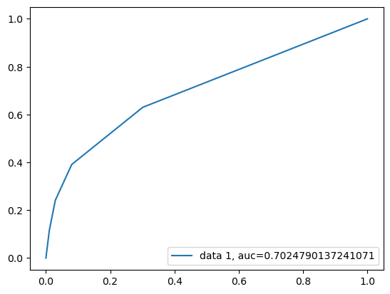

```python
from sklearn.neighbors import KNeighborsClassifier

knn = KNeighborsClassifier()
knn.fit(X_train_scaled, y_train)

y_pred = knn.predict(X_test_scaled)
y_prob = knn.predict_proba(X_test_scaled)[:,1]

print("K-Nearest Neighbors Report:")
print(classification_report(y_test, y_pred))

sns.heatmap(confusion_matrix(y_test, y_pred), annot=True, cmap="YlGnBu" ,fmt='g')
plt.title("Confusion Matrix - KNN")
plt.show()

y_pred_proba = knn.predict_proba(X_test_scaled)[::,1]
fpr, tpr, _ = metrics.roc_curve(y_test,  y_pred_proba)
auc = metrics.roc_auc_score(y_test, y_pred_proba)
plt.plot(fpr,tpr,label="data 1, auc="+str(auc))
plt.legend(loc=4)
plt.show()
```

## 3) Gaussian Naive Bayes

```
Gaussian Naive Bayes Report:
              precision    recall  f1-score   support

       False       0.92      0.92      0.92     10832
        True       0.40      0.42      0.41      1401

    accuracy                           0.86     12233
   macro avg       0.66      0.67      0.66     12233
weighted avg       0.86      0.86      0.86     12233
```

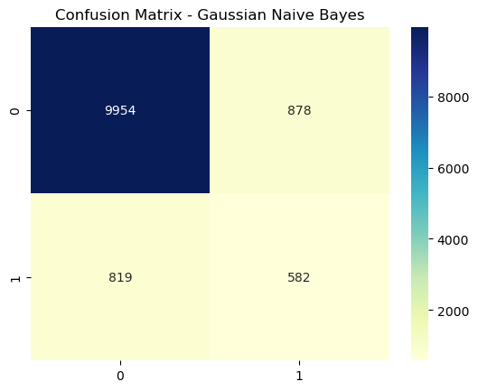

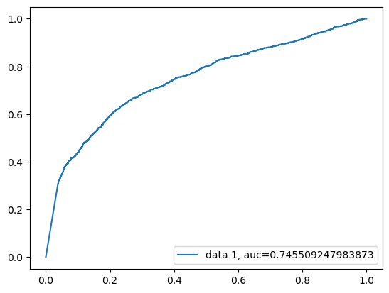

```python
from sklearn.naive_bayes import GaussianNB

nb = GaussianNB()
nb.fit(X_train, y_train)

y_pred = nb.predict(X_test)
y_prob = nb.predict_proba(X_test)[:,1]

print("Gaussian Naive Bayes Report:")
print(classification_report(y_test, y_pred))

sns.heatmap(confusion_matrix(y_test, y_pred), annot=True, cmap="YlGnBu" ,fmt='g')
plt.title("Confusion Matrix - Gaussian Naive Bayes")
plt.show()

y_pred_proba = nb.predict_proba(X_test)[::,1]
fpr, tpr, _ = metrics.roc_curve(y_test,  y_pred_proba)
auc = metrics.roc_auc_score(y_test, y_pred_proba)
plt.plot(fpr,tpr,label="data 1, auc="+str(auc))
plt.legend(loc=4)
plt.show()
```

## 4) Categorical Naive Bayes

```
Categorical Naive Bayes Report:
              precision    recall  f1-score   support

           0       0.94      0.84      0.88     10832
           1       0.31      0.58      0.41      1401

    accuracy                           0.81     12233
   macro avg       0.63      0.71      0.65     12233
weighted avg       0.87      0.81      0.83     12233
```

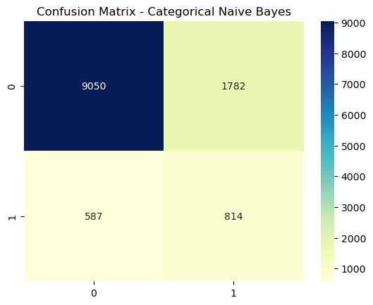

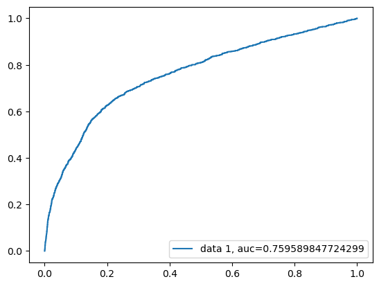

```python
from sklearn.naive_bayes import CategoricalNB

data = df.copy()

data['age_bin'] = pd.qcut(data['age'], q=4, labels=False)
data['campaign_bin'] = pd.qcut(data['campaign'].rank(method='first'), q=4, labels=False)
data['pdays_bin'] = pd.qcut(data['pdays'].rank(method='first'), q=4, labels=False)
data['previous_bin'] = pd.qcut(data['previous'].rank(method='first'), q=4, labels=False)
data['emp_bin'] = pd.qcut(data['emp.var.rate'], q=2, labels=False)
data['price_bin'] = pd.qcut(data['cons.price.idx'], q=3, labels=False)
data['conf_bin'] = pd.qcut(data['cons.conf.idx'], q=3, labels=False)

data = data.drop(['age', 'campaign', 'pdays', 'previous', 'emp.var.rate', 'cons.price.idx', 'cons.conf.idx'], axis=1)

for col in data.select_dtypes(include='bool').columns:
    data[col] = data[col].astype(int)

X_cnb = data.drop("y", axis=1)
y_cnb = data["y"]

X_train_cnb, X_test_cnb, y_train_cnb, y_test_cnb = train_test_split(X_cnb, y_cnb, test_size=0.3, random_state=25)

cnb = CategoricalNB()
cnb.fit(X_train_cnb, y_train_cnb)

y_pred_cnb = cnb.predict(X_test_cnb)
y_prob_cnb = cnb.predict_proba(X_test_cnb)[:, 1]

print("Categorical Naive Bayes Report:")
print(classification_report(y_test_cnb, y_pred_cnb))

sns.heatmap(confusion_matrix(y_test_cnb, y_pred_cnb), annot=True, cmap="YlGnBu", fmt='g')
plt.title("Confusion Matrix - Categorical Naive Bayes")
plt.show()

y_pred_proba = cnb.predict_proba(X_test_cnb)[::,1]
fpr, tpr, _ = metrics.roc_curve(y_test_cnb,  y_pred_proba)
auc = metrics.roc_auc_score(y_test_cnb, y_pred_proba)
plt.plot(fpr,tpr,label="data 1, auc="+str(auc))
plt.legend(loc=4)
plt.show()
```

## 5) Decision Tree

```
Decision Tree Report:
              precision    recall  f1-score   support

       False       0.91      0.90      0.91     10832
        True       0.30      0.32      0.31      1401

    accuracy                           0.84     12233
   macro avg       0.61      0.61      0.61     12233
weighted avg       0.84      0.84      0.84     12233
```

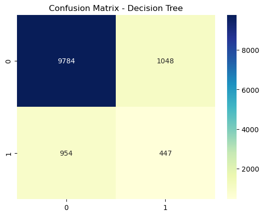

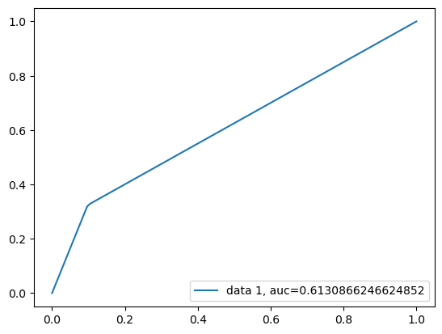

```python
from sklearn.tree import DecisionTreeClassifier

dt = DecisionTreeClassifier()
dt.fit(X_train, y_train)

y_pred = dt.predict(X_test)
y_prob = dt.predict_proba(X_test)[:,1]

print("Decision Tree Report:")
print(classification_report(y_test, y_pred))

sns.heatmap(confusion_matrix(y_test, y_pred), annot=True, cmap="YlGnBu" ,fmt='g')
plt.title("Confusion Matrix - Decision Tree")
plt.show()

y_pred_proba = dt.predict_proba(X_test)[::,1]
fpr, tpr, _ = metrics.roc_curve(y_test,  y_pred_proba)
auc = metrics.roc_auc_score(y_test, y_pred_proba)
plt.plot(fpr,tpr,label="data 1, auc="+str(auc))
plt.legend(loc=4)
plt.show()
```

## 6) Random Forest

```
Random Forest Report:
              precision    recall  f1-score   support

       False       0.91      0.97      0.94     10832
        True       0.53      0.27      0.36      1401

    accuracy                           0.89     12233
   macro avg       0.72      0.62      0.65     12233
weighted avg       0.87      0.89      0.87     12233
```

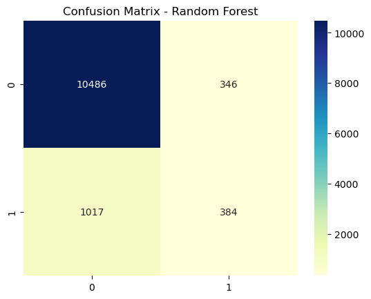

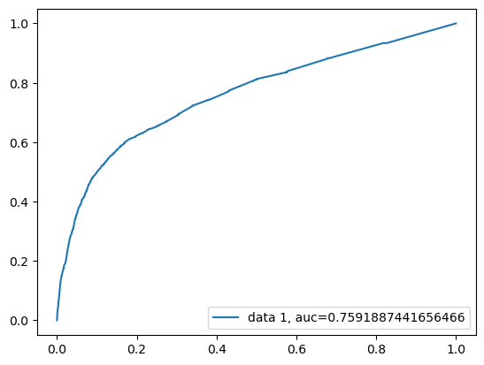

```python
from sklearn.ensemble import RandomForestClassifier

rf = RandomForestClassifier()
rf.fit(X_train, y_train)

y_pred = rf.predict(X_test)
y_prob = rf.predict_proba(X_test)[:,1]

print("Random Forest Report:")
print(classification_report(y_test, y_pred))

sns.heatmap(confusion_matrix(y_test, y_pred), annot=True, cmap="YlGnBu" ,fmt='g')
plt.title("Confusion Matrix - Random Forest")
plt.show()

y_pred_proba = rf.predict_proba(X_test)[::,1]
fpr, tpr, _ = metrics.roc_curve(y_test,  y_pred_proba)
auc = metrics.roc_auc_score(y_test, y_pred_proba)
plt.plot(fpr,tpr,label="data 1, auc="+str(auc))
plt.legend(loc=4)
plt.show()
```

## 7) XGBoost

```
XGBoost Report:
              precision    recall  f1-score   support

       False       0.91      0.97      0.94     10832
        True       0.58      0.27      0.37      1401

    accuracy                           0.89     12233
   macro avg       0.74      0.62      0.65     12233
weighted avg       0.87      0.89      0.88     12233
```

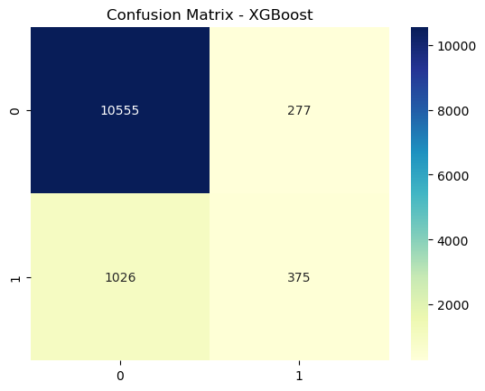

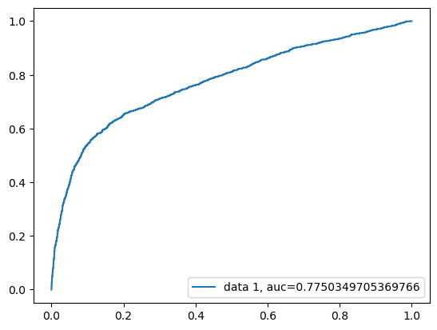

```python
from xgboost import XGBClassifier

xgb = XGBClassifier(eval_metric='logloss')
xgb.fit(X_train, y_train)

y_pred = xgb.predict(X_test)
y_prob = xgb.predict_proba(X_test)[:,1]

print("XGBoost Report:")
print(classification_report(y_test, y_pred))

sns.heatmap(confusion_matrix(y_test, y_pred), annot=True, cmap="YlGnBu" ,fmt='g')
plt.title("Confusion Matrix - XGBoost")
plt.show()

y_pred_proba = xgb.predict_proba(X_test)[::,1]
fpr, tpr, _ = metrics.roc_curve(y_test,  y_pred_proba)
auc = metrics.roc_auc_score(y_test, y_pred_proba)
plt.plot(fpr,tpr,label="data 1, auc="+str(auc))
plt.legend(loc=4)
plt.show()
```

# Hyperparameter Tuning of Decision Tree

```python
data = df.copy()
```

```python
for col in data.select_dtypes(include='bool').columns:
    data[col] = data[col].astype(int)
```

```python
X_tdt = data.drop("y", axis=1)
y_tdt = data["y"]
```

```python
X_train_tdt, X_test_tdt, y_train_tdt, y_test_tdt = train_test_split(X_tdt, y_tdt, test_size=0.3, random_state=25)
```

```python
tdt = DecisionTreeClassifier()
tdt.fit(X_train_tdt, y_train_tdt)
```

```
DecisionTreeClassifier()
```

## Initial Train and Test accuracy -

```python
dt.score(X_train_tdt, y_train_tdt), dt.score(X_test_tdt, y_test_tdt)
```

```
(0.9947796230117021, 0.8363443145589798)
```

## Initial tree visualization -

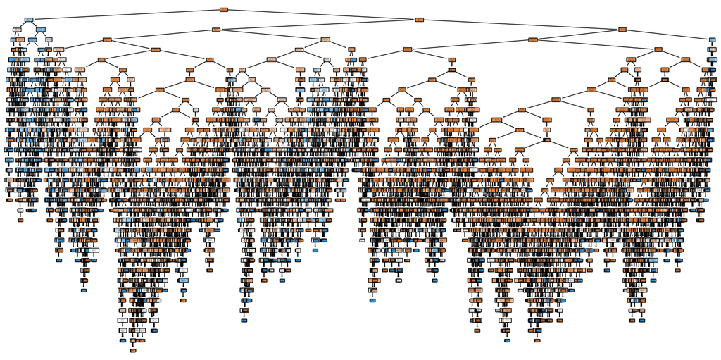

```python
from sklearn.tree import plot_tree
plt.figure(figsize=(20,10))
plot_tree(tdt, filled=True, feature_names=X_train_tdt.columns.tolist(), class_names=[str(cls) for cls in tdt.classes_])
plt.show()
```

## Initial tree structure -

```python
tree_info = tdt.tree_
num_nodes = tree_info.node_count
num_leaves = tree_info.n_leaves
num_decision = num_nodes - num_leaves

print("Number of nodes:", num_nodes)
print("Number of leaves:", num_leaves)
print("Number of decision:", num_decision)
```

```
Number of nodes: 8963
Number of leaves: 4482
Number of decision: 4481
```

## Tuning the 'max_depth' parameter and finding the accuracy -

```python
tdt = DecisionTreeClassifier(max_depth = 3, random_state=0)
tdt.fit(X_train_tdt, y_train_tdt)
tdt.score(X_train_tdt, y_train_tdt), tdt.score(X_test_tdt, y_test_tdt)
```

```
(0.9015836311400742, 0.8969181721572795)
```

## Visualizing the tree -

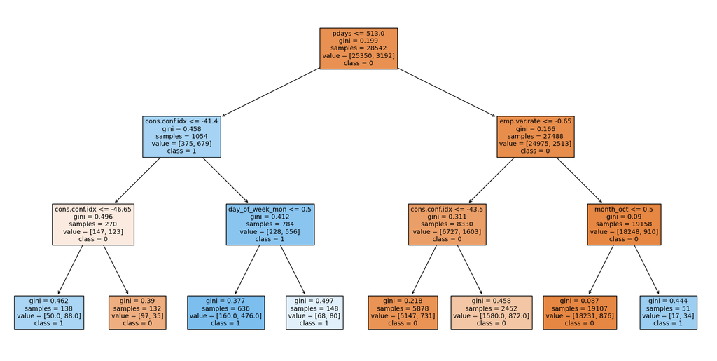

```
Number of nodes: 15
Number of leaves: 8
Number of decision: 7
```

```python
plt.figure(figsize=(20,10))
plot_tree(tdt, filled=True, feature_names=X_train_tdt.columns.tolist(), class_names=[str(cls) for cls in tdt.classes_])
plt.show()

tree_info = tdt.tree_
num_nodes = tree_info.node_count
num_leaves = tree_info.n_leaves
num_decision = num_nodes - num_leaves

print("Number of nodes:", num_nodes)
print("Number of leaves:", num_leaves)
print("Number of decision:", num_decision)
```

## Tuning the 'max_depth' parameter and finding the accuracy -

```python
tdt = DecisionTreeClassifier(max_depth = 4, random_state=0)
tdt.fit(X_train_tdt, y_train_tdt)
tdt.score(X_train_tdt, y_train_tdt), tdt.score(X_test_tdt, y_test_tdt)
```

```
(0.9020040641861117, 0.8970816643505273)
```

## Visualizing the tree -

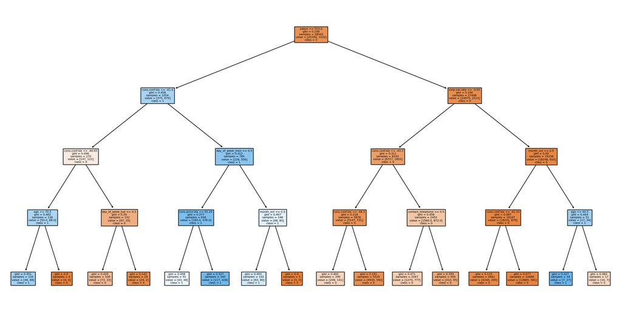

```
Number of nodes: 31
Number of leaves: 16
Number of decision: 15
```

```python
plt.figure(figsize=(20,10))
plot_tree(tdt, filled=True, feature_names=X_train_tdt.columns.tolist(), class_names=[str(cls) for cls in tdt.classes_])
plt.show()

tree_info = tdt.tree_
num_nodes = tree_info.node_count
num_leaves = tree_info.n_leaves
num_decision = num_nodes - num_leaves

print("Number of nodes:", num_nodes)
print("Number of leaves:", num_leaves)
print("Number of decision:", num_decision)
```

## Visualing the effect of different 'max_depth' values on model's performance -

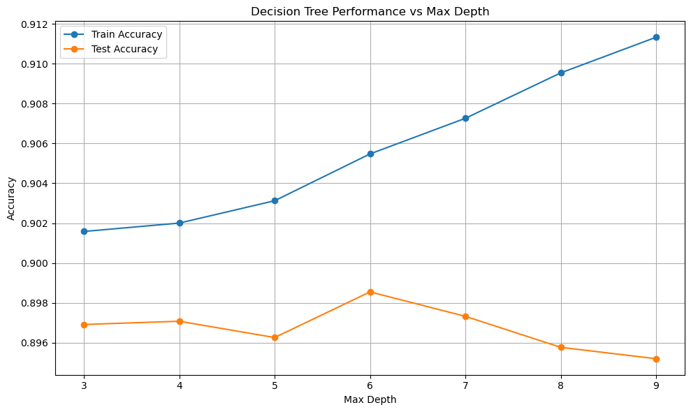

```python
depths = [3, 4, 5, 6, 7, 8, 9]
train_accuracies = []
test_accuracies = []

for depth in depths:
    tdt = DecisionTreeClassifier(max_depth=depth, random_state=0)
    tdt.fit(X_train_tdt, y_train_tdt)
    train_accuracies.append(tdt.score(X_train_tdt, y_train_tdt))
    test_accuracies.append(tdt.score(X_test_tdt, y_test_tdt))

plt.figure(figsize=(10, 6))
plt.plot(depths, train_accuracies, marker='o', label='Train Accuracy')
plt.plot(depths, test_accuracies, marker='o', label='Test Accuracy')
plt.title('Decision Tree Performance vs Max Depth')
plt.xlabel('Max Depth')
plt.ylabel('Accuracy')
plt.xticks(depths)
plt.grid(True)
plt.legend()
plt.tight_layout()
plt.show()
```

## Introducing another hyperparameter and visualing the effect of different 'min_samples_split' values on model's performance -

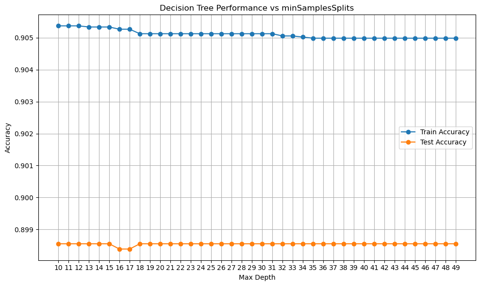

```python
minSamplesSplits = list(range(10, 50))
train_accuracies = []
test_accuracies = []

for minSamplesSplit in minSamplesSplits:
    tdt = DecisionTreeClassifier(max_depth=6, min_samples_split = minSamplesSplit, random_state=0)
    tdt.fit(X_train_tdt, y_train_tdt)
    train_accuracies.append(tdt.score(X_train_tdt, y_train_tdt))
    test_accuracies.append(tdt.score(X_test_tdt, y_test_tdt))

plt.figure(figsize=(10, 6))
plt.plot(minSamplesSplits, train_accuracies, marker='o', label='Train Accuracy')
plt.plot(minSamplesSplits, test_accuracies, marker='o', label='Test Accuracy')
plt.title('Decision Tree Performance vs minSamplesSplits')
plt.xlabel('Max Depth')
plt.ylabel('Accuracy')
plt.xticks(minSamplesSplits)
plt.grid(True)
plt.legend()
plt.tight_layout()
plt.show()
```

## Automating hyperparameter tuning by using Random Search Cross-Validation -

```python
from sklearn.model_selection import RandomizedSearchCV

param_dist = {
    'max_depth': list(range(2, 15)),
    'min_samples_split': list(range(10, 40)),
    'min_samples_leaf': list(range(10, 40)),
    'max_features': [None, 'sqrt', 'log2']
}

random_search = RandomizedSearchCV(
    estimator=DecisionTreeClassifier(random_state=0),
    param_distributions=param_dist,
    n_iter=100,
    cv=5,
    scoring='accuracy',
    n_jobs=-1,
    random_state=0,
    verbose=1
)

random_search.fit(X_train_tdt, y_train_tdt)
print("Best Parameters:", random_search.best_params_)

best_model = random_search.best_estimator_
test_score = best_model.score(X_test_tdt, y_test_tdt)
print("Test Set Score:", test_score)
```

```
Fitting 5 folds for each of 100 candidates, totalling 500 fits
Best Parameters: {'min_samples_split': 12, 'min_samples_leaf': 11, 'max_features': None, 'max_depth': 3}
Test Set Score: 0.8969181721572795
```

## Evaluating the model after hyperparameter tuning -

```python
tdt = DecisionTreeClassifier(min_samples_split=12, min_samples_leaf=11, max_features=None, max_depth=3)
tdt.fit(X_train_tdt, y_train_tdt)
tdt.score(X_train_tdt, y_train_tdt), tdt.score(X_test_tdt, y_test_tdt)
```

```
(0.9015836311400742, 0.8969181721572795)
```

## Visualizing the decision tree after hyperparameter tuning -

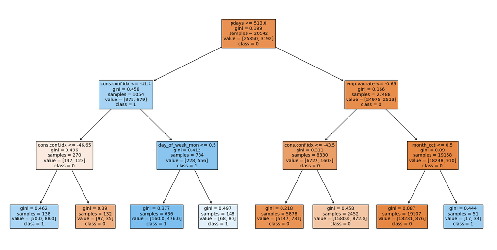

```
Number of nodes: 15
Number of leaves: 8
Number of decision: 7
```

```python
plt.figure(figsize=(20,10))
plot_tree(tdt, filled=True, feature_names=X_train_tdt.columns.tolist(), class_names=[str(cls) for cls in tdt.classes_])
plt.show()

tree_info = tdt.tree_
num_nodes = tree_info.node_count
num_leaves = tree_info.n_leaves
num_decision = num_nodes - num_leaves

print("Number of nodes:", num_nodes)
print("Number of leaves:", num_leaves)
print("Number of decision:", num_decision)
```